# homework-3

Lucas Maciel Balieiro

#### **1a. Análise Visual e Fatos Estilizados**

Primeiro, carregamos os pacotes necessários e obtemos os dados do Ibovespa (`^BVSP`). Em seguida, visualizamos a série de preços e de retornos para identificar os fatos estilizados.

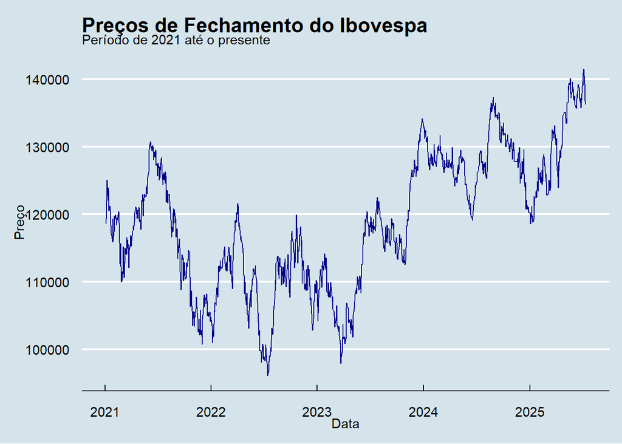

```r
library(tidyverse)
library(BatchGetSymbols)
library(forecast)
library(ggthemes)
library(tseries)
library(purrr)

# Obtenção dos dados
ibov <- BatchGetSymbols(tickers = "^BVSP",
                        first.date = '2021-01-01',
                        last.date = Sys.Date(),
                        type.return = "log",
                        freq.data = "daily")

ibov_df <- ibov$df.tickers
retornos_ibov <- na.omit(as.ts(ibov_df$ret.closing.prices))

# Gráfico de Preços de Fechamento
ggplot(ibov_df, aes(x = ref.date, y = price.close)) +
  geom_line(color = "darkblue") +
  labs(title = "Preços de Fechamento do Ibovespa",
       subtitle = "Período de 2021 até o presente",
       x = "Data", y = "Preço") +
  theme_economist()
```

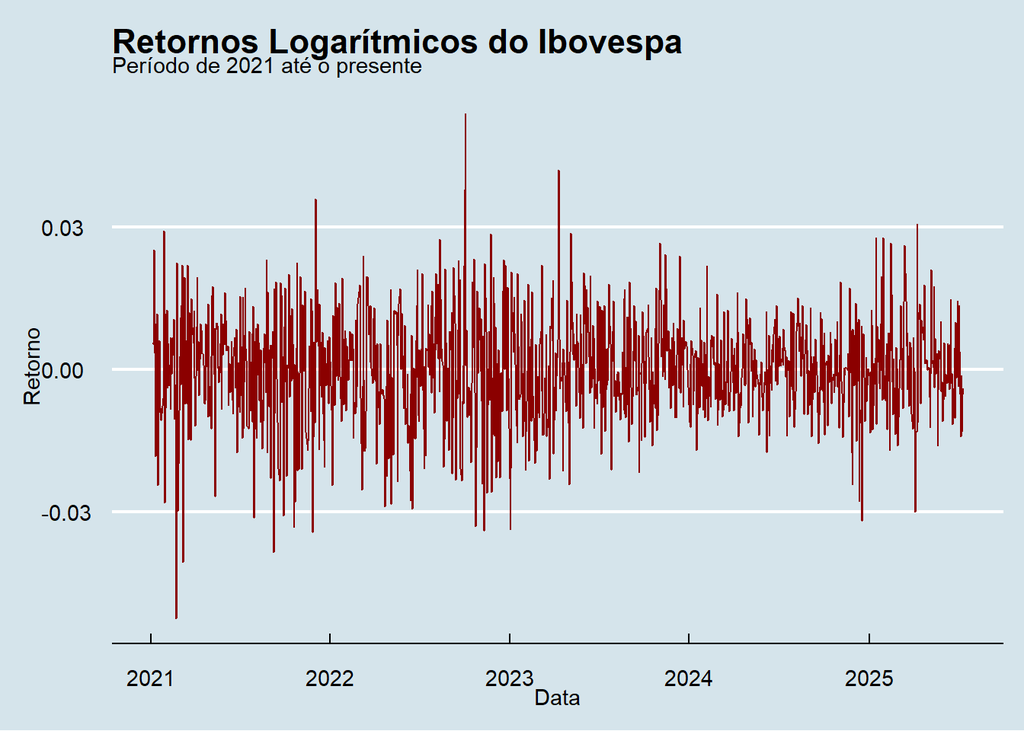

```r
# Gráfico de Retornos Logarítmicos
ggplot(ibov_df, aes(x = ref.date, y = ret.closing.prices)) +
  geom_line(color = "darkred") +
  labs(title = "Retornos Logarítmicos do Ibovespa",
       subtitle = "Período de 2021 até o presente",
       x = "Data", y = "Retorno") +
  theme_economist()
```

#### **1b. Análise da FAC e FACP**

Função de Autocorrelação (FAC) e a Função de Autocorrelação Parcial (FACP) para nos ajudar a identificar a ordem do modelo ARMA.

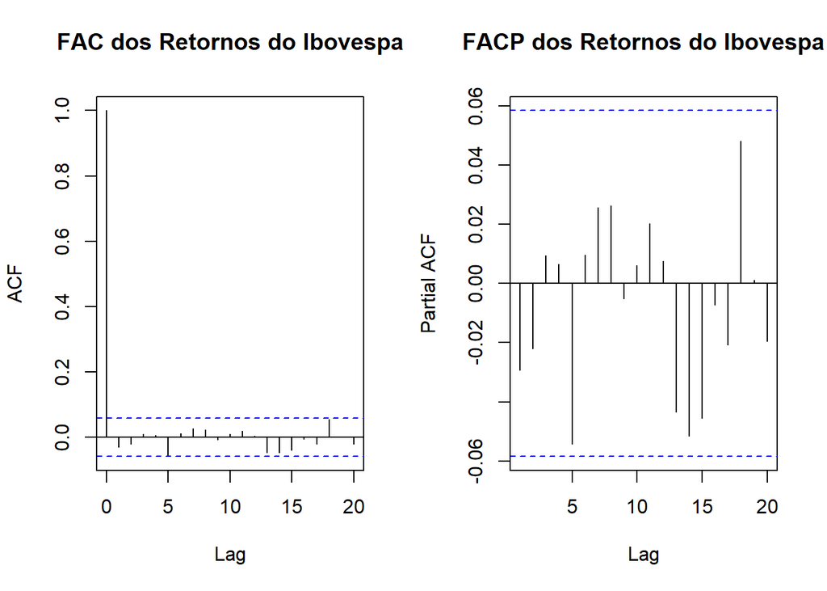

```r
par(mfrow=c(1, 2))
acf(retornos_ibov, main="FAC dos Retornos do Ibovespa", lag.max = 20)
pacf(retornos_ibov, main="FACP dos Retornos do Ibovespa", lag.max = 20)
```

```r
par(mfrow=c(1, 1))
```

#### **1c. Estimação do Modelo**

Utilizaremos a função `auto.arima()` como um ponto de partida para encontrar um bom modelo e depois o estimaremos manualmente para analisar os coeficientes e os critérios de informação (AIC e BIC).

```r
modelo_sugerido <- auto.arima(retornos_ibov, trace = FALSE, stationary = TRUE, seasonal = FALSE)
print(paste("Modelo sugerido por auto.arima:", arimaorder(modelo_sugerido)))
```

```
## [1] "Modelo sugerido por auto.arima: 0" "Modelo sugerido por auto.arima: 0"
## [3] "Modelo sugerido por auto.arima: 0"
```

```r
modelo_final_ibov <- Arima(retornos_ibov, order = arimaorder(modelo_sugerido))

cat("\n--- Resumo do Modelo Estimado ---\n")
```

```
##
## --- Resumo do Modelo Estimado ---
```

```r
print(modelo_final_ibov)
```

```
## Series: retornos_ibov
## ARIMA(0,0,0) with non-zero mean
##
## Coefficients:
##        mean
##       1e-04
## s.e.  3e-04
##
## sigma^2 = 0.0001301:  log likelihood = 3439.99
## AIC=-6875.99   AICc=-6875.97   BIC=-6865.93
```

```r
cat("\n--- Critérios de Informação ---\n")
```

```
##
## --- Critérios de Informação ---
```

```r
print(paste("AIC:", AIC(modelo_final_ibov)))
```

```
## [1] "AIC: -6875.98559252409"
```

```r
print(paste("BIC:", BIC(modelo_final_ibov)))
```

```
## [1] "BIC: -6865.93273890669"
```

O sumário do modelo mostra os coeficientes estimados e suas estatísticas (como o erro padrão), que podem ser usadas para calcular a estatística-t (`coef / s.e.`).

#### **1d. Diagnóstico dos Resíduos**

Verificamos se os resíduos do modelo se comportam como ruído branco, indicando que o modelo capturou toda a estrutura de autocorrelação presente nos dados.

```r
# Teste de Ljung-Box para autocorrelação nos resíduos
print(Box.test(residuals(modelo_final_ibov), type = "Ljung-Box", lag = 10))
```

```
##
##  Box-Ljung test
##
## data:  residuals(modelo_final_ibov)
## X-squared = 6.8686, df = 10, p-value = 0.7378
```

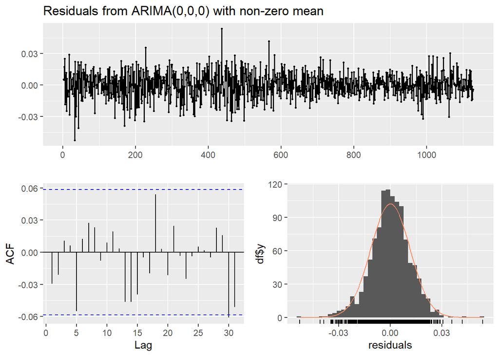

```
##
##  Ljung-Box test
##
## data:  Residuals from ARIMA(0,0,0) with non-zero mean
## Q* = 6.8686, df = 10, p-value = 0.7378
##
## Model df: 0.   Total lags used: 10
```

```r
checkresiduals(modelo_final_ibov)
```

A FAC dos resíduos não apresenta *lags* significativos e o p-valor do teste de Ljung-Box é alto (geralmente > 0.05), o que nos leva a **não rejeitar** a hipótese nula. Concluímos que os resíduos se comportam como ruído branco e o modelo é adequado.

### **2. Previsão para 5 Períodos**

Com o modelo escolhido e validado, calculamos as previsões estáticas para os próximos 5 dias, junto com seus respectivos intervalos de confiança de 95%.

```r
# Previsão para 5 períodos à frente
previsao_ibov <- forecast(modelo_final_ibov, h = 5)

print(previsao_ibov)
```

```
##      Point Forecast       Lo 80      Hi 80      Lo 95      Hi 95
## 1128   0.0001231143 -0.01449522 0.01474145 -0.0222337 0.02247993
## 1129   0.0001231143 -0.01449522 0.01474145 -0.0222337 0.02247993
## 1130   0.0001231143 -0.01449522 0.01474145 -0.0222337 0.02247993
## 1131   0.0001231143 -0.01449522 0.01474145 -0.0222337 0.02247993
## 1132   0.0001231143 -0.01449522 0.01474145 -0.0222337 0.02247993
```

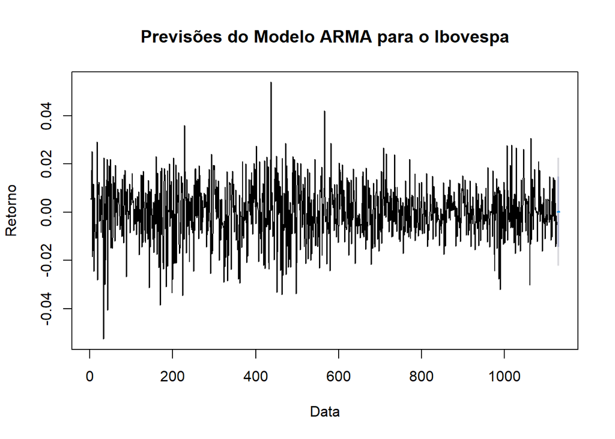

```r
plot(previsao_ibov,
     main = "Previsões do Modelo ARMA para o Ibovespa",
     xlab = "Data", ylab = "Retorno")
```

### **3. Modelo ARMA para Ações do S&P 500**

Nesta seção, baixamos os dados de todas as ações do S&P 500, estimamos um modelo ARMA para cada uma e criamos uma previsão de retorno para o dia seguinte (t+1).

```r
sp500_list <- GetSP500Stocks()

tickers <- sp500_list$Tickers

sp500_data <- BatchGetSymbols(tickers = tickers,
                              first.date = '2021-01-01',
                              last.date = Sys.Date(),
                              type.return = "log")

# Processamento e Modelagem
resultados_sp500 <- sp500_data$df.tickers %>%
  group_by(ticker) %>%
  summarise(
    modelo = if (n() > 30) list(auto.arima(ret.closing.prices, stationary = TRUE, seasonal = FALSE)) else list(NA),
    .groups = 'drop'
  ) %>%
  # Remove ações que não puderam ser modeladas
  filter(!is.na(modelo)) %>%
  mutate(
    previsao_t1 = map_dbl(modelo, ~forecast(.x, h = 1)$mean[1])
  )

maior_retorno_esperado <- resultados_sp500 %>%
  arrange(desc(previsao_t1)) %>%
  select(ticker, previsao_t1) %>%
  head(1)

cat("\n--- Ação do S&P 500 com Maior Expectativa de Retorno (t+1) ---\n")
```

```
##
## --- Ação do S&P 500 com Maior Expectativa de Retorno (t+1) ---
```

```r
print(maior_retorno_esperado)
```

```
## # A tibble: 1 × 2
##   ticker previsao_t1
##   <chr>        <dbl>
## 1 AES        0.00530
```

### **4. Estratégia de Negociação com Base em Previsões**

Por fim, investigamos se as previsões do modelo ARMA poderiam gerar uma estratégia de negociação lucrativa. Dividimos os dados em um conjunto de treino para estimar o modelo e um conjunto de teste para simular a estratégia.

```r
# Os dados ja estão baixados então já estou aproveitando
df <- sp500_data$df.tickers
data_corte <- as.Date('2024-01-01')

avaliar_estrategia <- function(dados_acao) {

  # Use tryCatch to handle any potential errors during the process
  tryCatch({

    treino <- dados_acao %>% filter(ref.date < data_corte)
    teste <- dados_acao %>% filter(ref.date >= data_corte)

    # Check for sufficient data
    if (nrow(treino) < 30 || nrow(teste) == 0) {
      # This return is now inside the tryCatch, but it's still valid.
      return(data.frame(
        ticker = character(0),
        retorno_total_estrategia = numeric(0),
        retorno_total_bh = numeric(0)
      ))
    }

    # Fit the model
    modelo <- auto.arima(treino$ret.closing.prices, stationary = TRUE, seasonal = FALSE)

    # Perform rolling forecast
    previsoes <- numeric(nrow(teste))
    for (i in 1:nrow(teste)) {
      dados_hist <- c(treino$ret.closing.prices, teste$ret.closing.prices[0:(i-1)])
      previsao_passo <- forecast(Arima(dados_hist, model=modelo), h=1)$mean[1]
      previsoes[i] <- previsao_passo
    }

    # Calculate strategy returns
    sinal <- ifelse(previsoes > 0, 1, 0) # 1 to Buy, 0 to Stay out
    retorno_estrategia <- sinal * teste$ret.closing.prices

    # Return the results data frame
    return(data.frame(
      ticker = first(dados_acao$ticker),
      retorno_total_estrategia = sum(retorno_estrategia),
      retorno_total_bh = sum(teste$ret.closing.prices)
    ))

  }, error = function(e) {
    # --- THIS IS THE FIX ---
    # If any error occurs in the block above, this 'error' function is called.
    # It returns an empty data frame with the correct structure, preventing the crash.
    # You can also print a message to know which ticker failed.
    cat("Error processing ticker:", first(dados_acao$ticker), "- Skipping.\n")
    return(data.frame(
      ticker = character(0),
      retorno_total_estrategia = numeric(0),
      retorno_total_bh = numeric(0)
    ))
  })
}

# This part of the code now runs without errors
filtered_df <- df %>%
  filter(ticker %in% tickers)

# 2. Split the filtered data frame into a list, with one data frame per ticker
list_of_dfs <- split(filtered_df, filtered_df$ticker)

# 3. Apply your function to each data frame in the list
# The map() function iterates through the list and collects the results.
results_list <- map(list_of_dfs, ~avaliar_estrategia(.x))

# 4. Combine the list of results back into a single data frame
# bind_rows() is very efficient for this task.
resultado_estrategia <- bind_rows(results_list)

# You can then proceed with your summary calculation
desempenho_geral <- resultado_estrategia %>%
  summarise(
    lucro_total_estrategia = sum(retorno_total_estrategia),
    lucro_total_buy_and_hold = sum(retorno_total_bh)
  )

cat("\n--- Comparativo de Lucro Acumulado (Estratégia vs. Buy and Hold) ---\n")
```

```
##
## --- Comparativo de Lucro Acumulado (Estratégia vs. Buy and Hold) ---
```

```r
print(desempenho_geral)
```

```
##   lucro_total_estrategia lucro_total_buy_and_hold
## 1               22.79786                 64.24016
```